# Track 1 Bikes Case Study- May

N. White

January 25, 2022 - January 27, 2022

# Cyclistic Bike Data

```r
install.packages("tidyverse")
library(tidyverse)
library(readr)
library(knitr)
library(dplyr)
library(lubridate)
```

### May

```r
May <- read_csv("202105-divvy-tripdata.csv")
May <- May %>%
  mutate(May, trip_duration5 = as.duration(ended_at - started_at))
May_filtered <- May %>%
    select(ride_id, rideable_type, started_at, ended_at, member_casual, trip_duration5) %>%
    filter(trip_duration5 > 5)

colnames(May)
```

```
##  [1] "ride_id"            "rideable_type"      "started_at"
##  [4] "ended_at"           "start_station_name" "start_station_id"
##  [7] "end_station_name"   "end_station_id"     "start_lat"
## [10] "start_lng"          "end_lat"            "end_lng"
## [13] "member_casual"      "trip_duration5"
```

#### Trips

```r
May_members <- May_filtered %>%
    filter(member_casual == "member")
May_casual <- May_filtered %>%
     filter(member_casual == "casual")
```

In May, we have 530441 trips. 256551 were by casual riders. 273890 were by annual members. We see that the trips in May made by annual members is nearly the same as casual riders.

#### Trip Length

```r
May_trip_avg <- (mean(May_filtered$trip_duration5))
May_m_trip_avg <- (mean(May_members$trip_duration5))
May_c_trip_avg <- (mean(May_casual$trip_duration5))
```

The average trip length in May was 1565 seconds (26 minutes). For members, the average trip duration was 880 seconds (14.6 minutes). For casual riders, the average trip length was 2297 seconds (38 minutes).

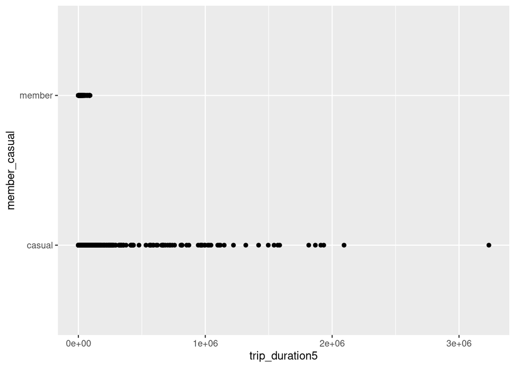

```r
ggplot(data = May_filtered, aes(x = trip_duration5, y = member_casual)) +
    geom_point()
```

#### Max Trip and Min Trip

Before filtering, the shortest trip by members was -13 seconds. Following is a trip of -1 seconds, and 24 trips of 0 seconds. For casual riders, the shortest trip was 0 seconds. This was for 28 individual trips.

The longest trip for members was 89996 seconds. The longest trip for casual riders is 3235296 seconds.

```r
May_c_trip_max <- (max(May_casual$trip_duration5))
May_m_trip_max <- (max(May_members$trip_duration5))
May_c_trip_min <- (min(May_casual$trip_duration5))
May_m_trip_min <- (min(May_members$trip_duration5))
```

#### Bike Type

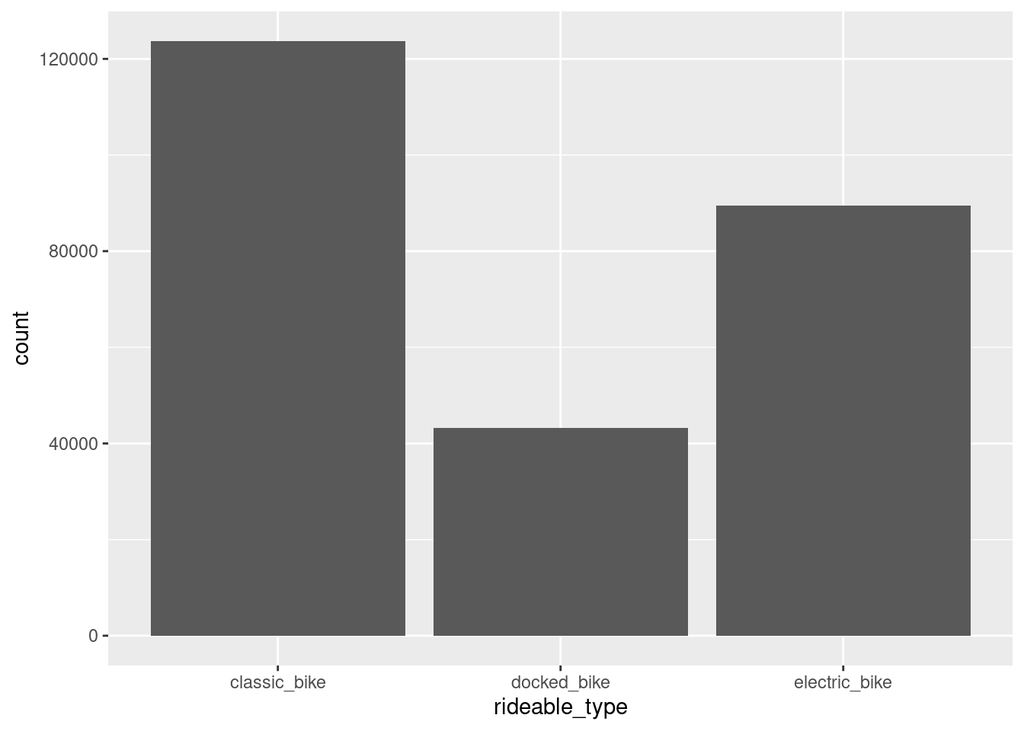

```r
May_c_elec <- length(which(May_casual$rideable_type == "electric_bike"))
May_c_classic <- length(which(May_casual$rideable_type == "classic_bike"))
May_c_docked <- length(which(May_casual$rideable_type == "docked_bike"))
ggplot(data = May_casual, aes(x = rideable_type)) +
     geom_bar()
```

Casual members took 123747 trips on classic bikes, 89503 trips on electric bikes, and 43301 trips on docked bikes.

[figure not shown]

```r
May_m_elec <- length(which(May_members$rideable_type == "electric_bike"))
May_m_classic <- length(which(May_members$rideable_type == "classic_bike"))
May_m_docked <- length(which(May_members$rideable_type == "docked_bike"))
ggplot(data = May_casual, aes(x = rideable_type)) +
     geom_bar()
```

Annual members took 184494 trips on classic bikes, 89396 trips on electric bikes, and none on docked bikes.